# Graphics: single shapes and Coo objects

Vincent Bonhomme

2014-09-07

Morphometrics are, by essence, highly concerned with shape graphics and the multivariate statistics we can turn them into. Here I review the core graphical functions. They are all derived from `base`graphics yet they may be turned into a `ggplot2` unified style at some point. They are presented in a “chronological” order, from operation on single shapes, to representation of `Coo` objects that are collections of shapes.

The (various) graphics that illustrate multivariate statistics are treated in the vignette dedicated to Multivariate analyses.

Note that graphics below may have a funny appearance. This is due to the restrictions on the graphics/vignettes sizes. Everything should be ok when code is runned on your machine.

# Shape graphics

### Single shape

`coo.plot` is the basic shape plotters in Momocs, used in many functions/methods. There is a bunch of options detailed exhaustively in `?coo.plot`, some are illustrated below.

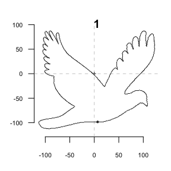

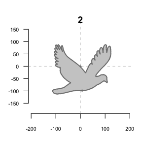

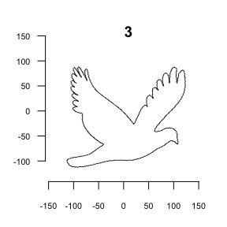

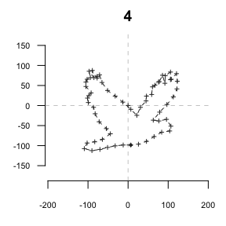

```r
library(Momocs)
data(shapes)
shp <- coo.center(shapes[22])
coo.plot(shp)
title(1)
coo.plot(shp, col = "grey80", border = "grey50", lwd = 2,
         zoom = 1.5, )
title(2)
coo.plot(shp, ylim=c(-130, 150),
         xy.axis = FALSE, first.point = FALSE, centroid=FALSE)
title(3)
coo.plot(coo.sample(shp, 64), lty=2, pch=3, points = TRUE, zoom=1.5, main="4")
```

### Add shape(s)

`coo.draw` is a shortcut for adding a shape to an existing plot. First, we shift to the `wings` dataset. See `?wings` for details and credits.

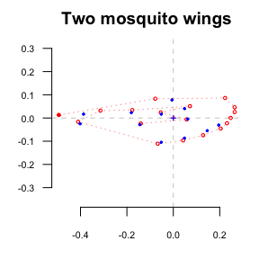

```r
data(wings)
w1 <- wings[1]
w2 <- wings[2]
coo.plot(w1, border = "#FF0000", lwd = 0.5, lty = 3, main="Two mosquito wings")
coo.draw(w2, border="#0000FF", col=.transp("000FF", 0.9), poly=FALSE, pch=20)
```

Note that the red-dotted outlines are not biologically relevant, since we want to display landmark positions, with some of them being within the wings. In other words, this should not be drawn as a polygon. That is what we have done with the second shape, with the blue dots, by passing `poly=FALSE`, for `coo.draw` which simply adds a shape in the existing graphical window.

### Two shapes: differences

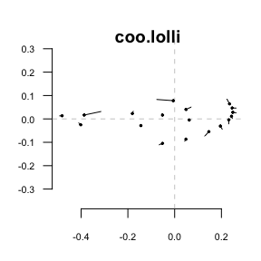

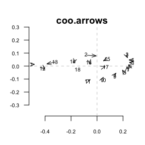

```r
coo.lolli(w1, w2, main="coo.lolli")
coo.arrows(w1, w2, main="coo.arrows")
ldk.labels(w1)
```

### Two shapes: Thin plate splines

We will extract the mean shapes of whisky and beer bottles, from the bottles dataset. We have seen the first two steps before. We add some custom arguments to the `tps.` family but it “works” with only the first two.

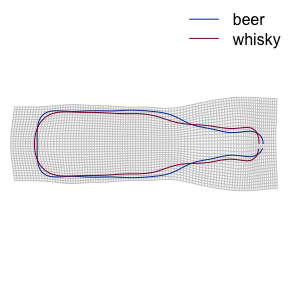

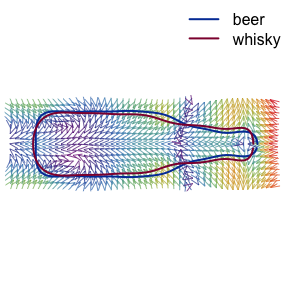

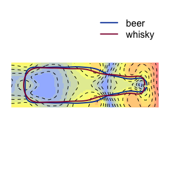

```r
data(bot)
bot.f <- eFourier(bot, 12)
ms <- mshapes(bot.f, "type") #mshapes 'type'-wise, see bot.f$fac
whisky <- ms$shp$whisky
beer   <- ms$shp$beer
tps.grid(beer, whisky, grid.size = 30, amp=2)
tps.arr(beer, whisky, amp=2, palette=col.summer2)
tps.iso(beer, whisky, amp=2, palette=col.spring)
```

# `Coo` objects: collection of shapes

Let’s work on the main objects of Momocs: `Coo` objects. Whether, we are working with `Out`, `Opn` or `Ldk` we roughly want the same thing: check singles shapes within them or plot them all, as a family picture or on the same window.

```r
data(bot)
```

### Quick inspection

`Coo` objects can be directly plot, with the old-friend `plot`. If `id` is not specified, then random shapes are plotted and you will be asked to press `<Enter>` to continue your inspection.

```r
plot(bot) # random inspection (not shown)
```

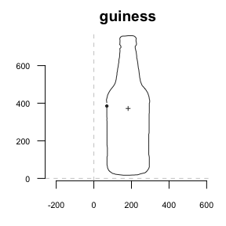

```r
plot(bot, 9) # let's go for a stout
```

### Panel

You may want to present all your data. That is a job for `panel`. Mind that shapes are templated with `coo.template` and size differences will thus be tempered (if not completely invisible). You can use a combination of `fac` and `reorder` to present graphically your groups.

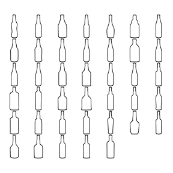

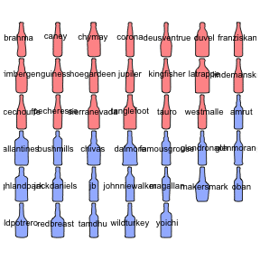

```r
panel(bot)
panel(bot, fac = "type", palette=col.spring, names=TRUE)
```

### Stack

Have a look to this method: it plots all the shapes on the same window. It is obvious that shapes are neither centered nor scaled. Also, the first point of their outlines varies along their left side. This may be important to take into account, depending on the subsequent analyses (*e.g* `eFourier`).

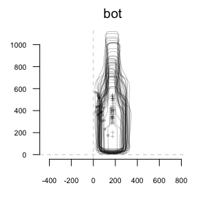

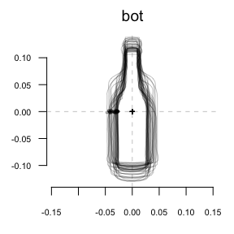

```r
stack(bot)
bot <- coo.slidedirection(coo.scale(coo.center(bot)), "W")
stack(bot)
```

### Others `Coo` objects

The functions presented above on `Out` can be applied to `Opn` and `Ldk`.

```r
data(olea) # Opn
class(olea)
```

```
## [1] "Opn" "Coo"
```

```r
panel(olea)
stack(olea)

data(wings) # Ldk
class(wings)
```

```
## [1] "Ldk" "Coo"
```

[figure not shown]

[figure not shown]

[figure not shown]

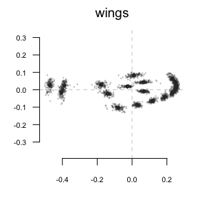

```r
panel(wings)
stack(wings)
```

Note that `Ldk` specific functions will be improved in a further version, to include, among other things, links between landmarks.

# `Coe` objects: morphometric coefficients

Some graphic function also apply on `Coe` objects.

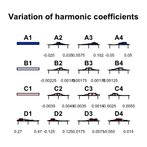

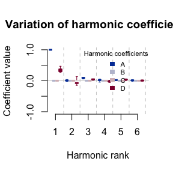

```r
bot.f <- eFourier(bot, 12)
hist(bot.f)
boxplot(bot.f)
```

You can also pass `Coo` methods to `Coe` objects. Momocs will thus use the inverse transformation to how well (or bad) morphometric coefficients have capture shape structure.

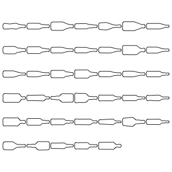

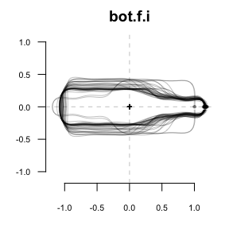

```r
panel(bot.f)
stack(bot.f)
```

These functions also work on `OpnCoe` and on `LdkCoe`:

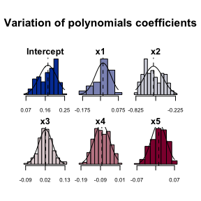

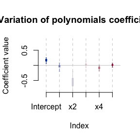

[figure not shown]

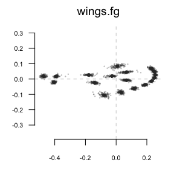

```r
olea.p <- orthoPolynomials(olea, degree = 5, nb.pts = 50)
hist(olea.p)
boxplot(olea.p)
#todo
#panel(olea.p)
#stack(olea.p)

wings.fg <- fgProcrustes(wings, verbose = FALSE)
#todo
#hist(wings.fg)
#boxplot(wings.fg)
panel(wings.fg)
stack(wings.fg)
```